# Biostat 203B Homework 3

Due Feb 23 @ 11:59PM

Author

Yuxin Zhang and 406328706

Load necessary libraries (you can add more as needed).

```r
library(arrow)
library(memuse)
library(pryr)
library(R.utils)
library(tidyverse)
```

Display your machine memory.

```r
memuse::Sys.meminfo()
```

```
Totalram:  16.000 GiB
Freeram:   90.672 MiB
```

In this exercise, we use tidyverse (ggplot2, dplyr, etc) to explore the [MIMIC-IV](https://mimic.mit.edu/docs/iv/) data introduced in [homework 1](https://ucla-biostat-203b.github.io/2024winter/hw/hw1/hw1.html) and to build a cohort of ICU stays.

## Q1. Visualizing patient trajectory

Visualizing a patient’s encounters in a health care system is a common task in clinical data analysis. In this question, we will visualize a patient’s ADT (admission-discharge-transfer) history and ICU vitals in the MIMIC-IV data.

### Q1.1 ADT history

A patient’s ADT history records the time of admission, discharge, and transfer in the hospital. This figure shows the ADT history of the patient with `subject_id` 10001217 in the MIMIC-IV data. The x-axis is the calendar time, and the y-axis is the type of event (ADT, lab, procedure). The color of the line segment represents the care unit. The size of the line segment represents whether the care unit is an ICU/CCU. The crosses represent lab events, and the shape of the dots represents the type of procedure. The title of the figure shows the patient’s demographic information and the subtitle shows top 3 diagnoses.

[figure not shown]

Do a similar visualization for the patient with `subject_id` 10013310 using ggplot.

Hint: We need to pull information from data files `patients.csv.gz`, `admissions.csv.gz`, `transfers.csv.gz`, `labevents.csv.gz`, `procedures_icd.csv.gz`, `diagnoses_icd.csv.gz`, `d_icd_procedures.csv.gz`, and `d_icd_diagnoses.csv.gz`. For the big file `labevents.csv.gz`, use the Parquet format you generated in Homework 2. For reproducibility, make the Parquet folder `labevents_pq` available at the current working directory `hw3`, for example, by a symbolic link. Make your code reproducible.

#### Answer

```bash
ln -s ../hw2/labevents_pq  labevents_pq
```

patient of interest:

```r
sid <- 10001217
```

```r
sid_adt <- read_csv("~/mimic/hosp/transfers.csv.gz") %>%
  filter(subject_id == sid & eventtype != "discharge") %>%
  print(width = Inf)
```

```
# A tibble: 10 × 7
   subject_id  hadm_id transfer_id eventtype careunit
        <dbl>    <dbl>       <dbl> <chr>     <chr>
 1   10001217 24597018    30437372 transfer  Neurology
 2   10001217 24597018    35343802 transfer  Neurology
 3   10001217 24597018    37058438 admit     Medicine
 4   10001217 24597018    37067082 transfer  Surgical Intensive Care Unit (SICU)
 5   10001217 24597018    39866888 ED        Emergency Department
 6   10001217 27703517    33261790 admit     Neurology
 7   10001217 27703517    34592300 transfer  Surgical Intensive Care Unit (SICU)
 8   10001217 27703517    34609030 transfer  Neurology
 9   10001217 27703517    37436471 transfer  Neurology
10   10001217       NA    39300221 ED        Emergency Department
   intime              outtime
   <dttm>              <dttm>
 1 2157-11-24 15:32:32 2157-11-25 18:11:46
 2 2157-11-21 22:08:00 2157-11-24 15:32:32
 3 2157-11-19 01:24:00 2157-11-20 19:18:02
 4 2157-11-20 19:18:02 2157-11-21 22:08:00
 5 2157-11-18 17:38:00 2157-11-19 01:24:00
 6 2157-12-18 16:59:25 2157-12-18 18:23:43
 7 2157-12-19 15:42:24 2157-12-20 14:27:41
 8 2157-12-18 18:23:43 2157-12-19 15:42:24
 9 2157-12-20 14:27:41 2157-12-24 14:58:42
10 2157-11-29 19:28:00 2157-11-29 21:22:00
```

```r
sid_lab <- arrow::open_dataset("labevents_pq") |>
  filter(subject_id == sid) |>
  collect() |>
  print(width = Inf)
```

```
# A tibble: 353 × 16
   labevent_id subject_id  hadm_id specimen_id itemid order_provider_id
         <int>      <int>    <int>       <int>  <int> <chr>
 1        9291   10001217 27703517    73688730  51248 ""
 2        9292   10001217 27703517    73688730  51249 ""
 3        9293   10001217 27703517    73688730  51250 ""
 4        9294   10001217 27703517    73688730  51265 ""
 5        9295   10001217 27703517    73688730  51277 ""
 6        9296   10001217 27703517    73688730  51279 ""
 7        9297   10001217 27703517    73688730  51301 ""
 8        9298   10001217 27703517    86955433  51009 ""
 9        8945   10001217       NA    17915844  50887 ""
10        8946   10001217       NA    27706469  51146 ""
   charttime           storetime
   <dttm>              <dttm>
```

[output cut: 35 more lines]

```r
sid_hpcd <- read_csv("~/mimic/hosp/procedures_icd.csv.gz") %>%
  filter(subject_id == sid) %>%
  mutate(chartdate = as.POSIXct(chartdate)) %>%
  print(width = Inf)
```

```
# A tibble: 4 × 6
  subject_id  hadm_id seq_num chartdate           icd_code icd_version
       <dbl>    <dbl>   <dbl> <dttm>              <chr>          <dbl>
1   10001217 24597018       1 2157-11-20 00:00:00 0139               9
2   10001217 24597018       2 2157-11-19 00:00:00 0331               9
3   10001217 24597018       3 2157-11-22 00:00:00 3897               9
4   10001217 27703517       1 2157-12-19 00:00:00 0139               9
```

```r
sid_ipcd <- read_csv("~/mimic/hosp/d_icd_procedures.csv.gz") |>
  print(width = Inf)
```

```
# A tibble: 85,257 × 3
   icd_code icd_version
   <chr>          <dbl>
 1 0001               9
 2 0002               9
 3 0003               9
 4 0009               9
 5 001               10
 6 0010               9
 7 0011               9
 8 0012               9
 9 0013               9
10 0014               9
   long_title
   <chr>
 1 Therapeutic ultrasound of vessels of head and neck
 2 Therapeutic ultrasound of heart
 3 Therapeutic ultrasound of peripheral vascular vessels
 4 Other therapeutic ultrasound
 5 Central Nervous System and Cranial Nerves, Bypass
 6 Implantation of chemotherapeutic agent
 7 Infusion of drotrecogin alfa (activated)
 8 Administration of inhaled nitric oxide
 9 Injection or infusion of nesiritide
10 Injection or infusion of oxazolidinone class of antibiotics
# ℹ 85,247 more rows
```

```r
sid_pcd <- left_join(sid_hpcd , sid_ipcd, by = "icd_code") |>
  print(width = Inf)
```

```
# A tibble: 4 × 8
  subject_id  hadm_id seq_num chartdate           icd_code icd_version.x
       <dbl>    <dbl>   <dbl> <dttm>              <chr>            <dbl>
1   10001217 24597018       1 2157-11-20 00:00:00 0139                 9
2   10001217 24597018       2 2157-11-19 00:00:00 0331                 9
3   10001217 24597018       3 2157-11-22 00:00:00 3897                 9
4   10001217 27703517       1 2157-12-19 00:00:00 0139                 9
  icd_version.y long_title
          <dbl> <chr>
1             9 Other incision of brain
2             9 Spinal tap
3             9 Central venous catheter placement with guidance
4             9 Other incision of brain
```

```r
sid_pat <- read_csv("~/mimic/hosp/patients.csv.gz") |>
  filter(subject_id == sid) |>
  print(width = Inf)
```

```
# A tibble: 1 × 6
  subject_id gender anchor_age anchor_year anchor_year_group dod
       <dbl> <chr>       <dbl>       <dbl> <chr>             <date>
1   10001217 F              55        2157 2011 - 2013       NA
```

```r
sid_ad <- read_csv("~/mimic/hosp/admissions.csv.gz") |>
  filter(subject_id == sid) |>
  print(width = Inf)
```

```
# A tibble: 2 × 16
  subject_id  hadm_id admittime           dischtime           deathtime
       <dbl>    <dbl> <dttm>              <dttm>              <dttm>
1   10001217 24597018 2157-11-18 22:56:00 2157-11-25 18:00:00 NA
2   10001217 27703517 2157-12-18 16:58:00 2157-12-24 14:55:00 NA
  admission_type admit_provider_id admission_location discharge_location
  <chr>          <chr>             <chr>              <chr>
1 EW EMER.       P4645A            EMERGENCY ROOM     HOME HEALTH CARE
2 DIRECT EMER.   P99698            PHYSICIAN REFERRAL HOME HEALTH CARE
  insurance language marital_status race  edregtime
  <chr>     <chr>    <chr>          <chr> <dttm>
1 Other     ?        MARRIED        WHITE 2157-11-18 17:38:00
2 Other     ?        MARRIED        WHITE NA
  edouttime           hospital_expire_flag
  <dttm>                             <dbl>
1 2157-11-19 01:24:00                    0
2 NA                                     0
```

```r
sid_dgn <- read_csv("~/mimic/hosp/diagnoses_icd.csv.gz") |>
  filter(subject_id == sid) |>
  print(width = Inf)
```

```
# A tibble: 17 × 5
   subject_id  hadm_id seq_num icd_code icd_version
        <dbl>    <dbl>   <dbl> <chr>          <dbl>
 1   10001217 24597018       1 3240               9
 2   10001217 24597018       2 3484               9
 3   10001217 24597018       3 3485               9
 4   10001217 24597018       4 5180               9
 5   10001217 24597018       5 340                9
 6   10001217 24597018       6 04109              9
 7   10001217 24597018       7 3051               9
 8   10001217 24597018       8 4019               9
 9   10001217 24597018       9 V168               9
10   10001217 24597018      10 V161               9
11   10001217 27703517       1 3240               9
12   10001217 27703517       2 3485               9
13   10001217 27703517       3 340                9
14   10001217 27703517       4 04102              9
15   10001217 27703517       5 04184              9
16   10001217 27703517       6 4019               9
17   10001217 27703517       7 3051               9
```

```r
sid_ddgn <- read_csv("~/mimic/hosp/d_icd_diagnoses.csv.gz")
top_sid_ddgn <- sid_dgn %>%
  slice_head(n = 3) %>%
  ungroup() %>%
  inner_join(sid_ddgn, by = "icd_code") %>%
  print(width = Inf)
```

```
# A tibble: 3 × 7
  subject_id  hadm_id seq_num icd_code icd_version.x icd_version.y
       <dbl>    <dbl>   <dbl> <chr>            <dbl>         <dbl>
1   10001217 24597018       1 3240                 9             9
2   10001217 24597018       2 3484                 9             9
3   10001217 24597018       3 3485                 9             9
  long_title
  <chr>
1 Intracranial abscess
2 Compression of brain
3 Cerebral edema
```

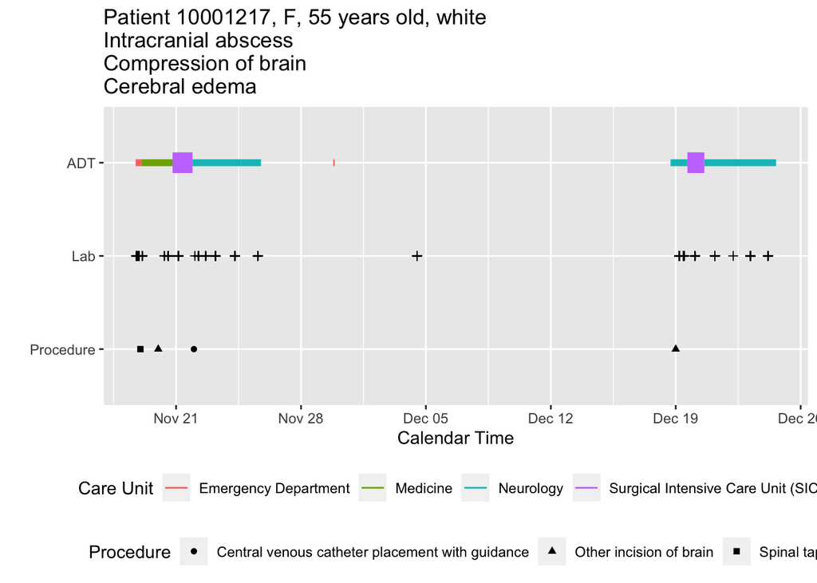

```r
  ggplot() +
  geom_segment(data = sid_adt, aes(
    x = intime,
    xend = outtime,
    y = "ADT",
    yend = "ADT",
    color = careunit,
    linewidth = str_detect(careunit, "(ICU|CCU)")))+
    scale_linewidth_discrete(guide = "none")+
  geom_point(data = sid_lab,
             mapping = aes(
               x = charttime,
               y = "Lab"),
             shape = 3
             ) +
  geom_point(data = sid_pcd,
           mapping = aes(
             x = chartdate,
             y = "Procedure",
             shape = long_title
           )) +
  labs(
    x = "Calendar Time",
    y = "",
    shape = "Procedure",
    color = "Care Unit",
    title = str_c(
  "Patient ", sid, ", ",
  sid_pat$gender, ", ",
  sid_pat$anchor_age, " years old, ",
  tolower(sid_ad$race), "\n",
  paste(paste(top_sid_ddgn$long_title[1:3]), collapse = "\n"))
 )+
  scale_y_discrete(
    limits = c("Procedure", "Lab", "ADT"),
  ) +
  theme(
    legend.position = "bottom",
    legend.box = "vertical"
  )
```

### Q1.2 ICU stays

ICU stays are a subset of ADT history. This figure shows the vitals of the patient `10001217` during ICU stays. The x-axis is the calendar time, and the y-axis is the value of the vital. The color of the line represents the type of vital. The facet grid shows the abbreviation of the vital and the stay ID.

[figure not shown]

Do a similar visualization for the patient `10013310`.

#### Answer

```bash
ln -s ../hw2/chartevents_pq  chartevents_pq
```

```r
sid_ite <- read_csv("~/mimic/icu/d_items.csv.gz") |>
  filter(abbreviation %in% c("HR", "NBPd", "NBPs", "RR", "Temperature F")) |>
  print(width = Inf)
```

```
# A tibble: 5 × 9
  itemid label                                 abbreviation  linksto
   <dbl> <chr>                                 <chr>         <chr>
1 220045 Heart Rate                            HR            chartevents
2 220179 Non Invasive Blood Pressure systolic  NBPs          chartevents
3 220180 Non Invasive Blood Pressure diastolic NBPd          chartevents
4 220210 Respiratory Rate                      RR            chartevents
5 223761 Temperature Fahrenheit                Temperature F chartevents
  category            unitname param_type lownormalvalue highnormalvalue
  <chr>               <chr>    <chr>               <dbl>           <dbl>
1 Routine Vital Signs bpm      Numeric                NA              NA
2 Routine Vital Signs mmHg     Numeric                NA              NA
3 Routine Vital Signs mmHg     Numeric                NA              NA
4 Respiratory         insp/min Numeric                NA              NA
5 Routine Vital Signs °F       Numeric                NA              NA
```

```r
sid_cet <- arrow::open_dataset("chartevents_pq") |>
  filter(subject_id == sid) |>
  collect() |>
  inner_join(sid_ite, by = "itemid") |>
  mutate(value = as.numeric(value)) |>
  print(width = Inf)
```

```
# A tibble: 219 × 19
   subject_id  hadm_id  stay_id caregiver_id charttime
        <int>    <int>    <int>        <int> <dttm>
 1   10001217 24597018 37067082         7355 2157-11-21 11:00:00
 2   10001217 24597018 37067082         7355 2157-11-21 11:00:00
 3   10001217 24597018 37067082         7355 2157-11-21 11:00:00
 4   10001217 24597018 37067082         7355 2157-11-21 11:00:00
 5   10001217 24597018 37067082         7355 2157-11-21 11:00:00
 6   10001217 24597018 37067082         7355 2157-11-21 12:00:00
 7   10001217 24597018 37067082         7355 2157-11-21 12:00:00
 8   10001217 24597018 37067082         7355 2157-11-21 12:00:00
 9   10001217 24597018 37067082         7355 2157-11-21 12:00:00
10   10001217 24597018 37067082         7355 2157-11-21 13:00:00
   storetime           itemid value valuenum valueuom warning
   <dttm>               <dbl> <dbl>    <dbl> <chr>      <int>
```

[output cut: 35 more lines]

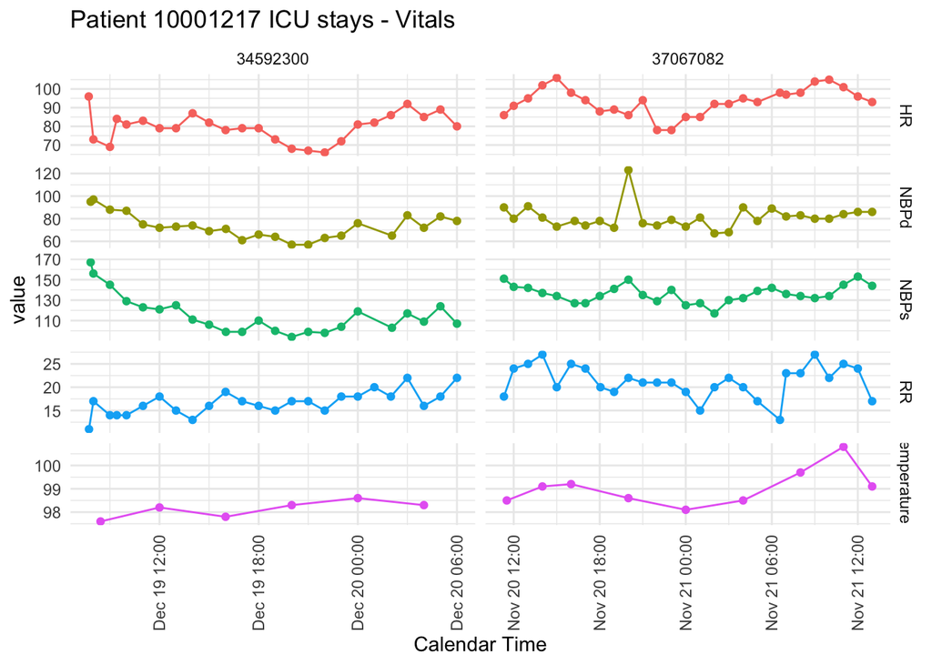

```r
ggplot(sid_cet, aes(x = charttime, y =value,
                    color = abbreviation)) +
  geom_line() +
  geom_point() +
  facet_grid(abbreviation ~ stay_id, scales = "free", space = "fixed") +
  labs(x = "Calendar Time", title = paste("Patient", sid, "ICU stays - Vitals")) +
  theme_minimal() +
  theme(
    legend.position = "none",
    axis.text.x = element_text(angle = 90, vjust = 0.5)
  )
```

## Q2. ICU stays

`icustays.csv.gz` (https://mimic.mit.edu/docs/iv/modules/icu/icustays/) contains data about Intensive Care Units (ICU) stays. The first 10 lines are

```bash
zcat < ~/mimic/icu/icustays.csv.gz | head
```

```
subject_id,hadm_id,stay_id,first_careunit,last_careunit,intime,outtime,los
10000032,29079034,39553978,Medical Intensive Care Unit (MICU),Medical Intensive Care Unit (MICU),2180-07-23 14:00:00,2180-07-23 23:50:47,0.4102662037037037
10000980,26913865,39765666,Medical Intensive Care Unit (MICU),Medical Intensive Care Unit (MICU),2189-06-27 08:42:00,2189-06-27 20:38:27,0.4975347222222222
10001217,24597018,37067082,Surgical Intensive Care Unit (SICU),Surgical Intensive Care Unit (SICU),2157-11-20 19:18:02,2157-11-21 22:08:00,1.1180324074074075
10001217,27703517,34592300,Surgical Intensive Care Unit (SICU),Surgical Intensive Care Unit (SICU),2157-12-19 15:42:24,2157-12-20 14:27:41,0.9481134259259258
10001725,25563031,31205490,Medical/Surgical Intensive Care Unit (MICU/SICU),Medical/Surgical Intensive Care Unit (MICU/SICU),2110-04-11 15:52:22,2110-04-12 23:59:56,1.338587962962963
10001884,26184834,37510196,Medical Intensive Care Unit (MICU),Medical Intensive Care Unit (MICU),2131-01-11 04:20:05,2131-01-20 08:27:30,9.171817129629629
10002013,23581541,39060235,Cardiac Vascular Intensive Care Unit (CVICU),Cardiac Vascular Intensive Care Unit (CVICU),2160-05-18 10:00:53,2160-05-19 17:33:33,1.3143518518518518
10002155,20345487,32358465,Medical Intensive Care Unit (MICU),Medical Intensive Care Unit (MICU),2131-03-09 21:33:00,2131-03-10 18:09:21,0.8585763888888889
10002155,23822395,33685454,Coronary Care Unit (CCU),Coronary Care Unit (CCU),2129-08-04 12:45:00,2129-08-10 17:02:38,6.178912037037037
```

### Q2.1 Ingestion

Import `icustays.csv.gz` as a tibble `icustays_tble`.

#### Answer

```r
icustays_tble <- read_csv("~/mimic/icu/icustays.csv.gz") |>
  as_tibble() |>
  print(width = Inf)
```

```
# A tibble: 73,181 × 8
   subject_id  hadm_id  stay_id first_careunit
        <dbl>    <dbl>    <dbl> <chr>
 1   10000032 29079034 39553978 Medical Intensive Care Unit (MICU)
 2   10000980 26913865 39765666 Medical Intensive Care Unit (MICU)
 3   10001217 24597018 37067082 Surgical Intensive Care Unit (SICU)
 4   10001217 27703517 34592300 Surgical Intensive Care Unit (SICU)
 5   10001725 25563031 31205490 Medical/Surgical Intensive Care Unit (MICU/SICU)
 6   10001884 26184834 37510196 Medical Intensive Care Unit (MICU)
 7   10002013 23581541 39060235 Cardiac Vascular Intensive Care Unit (CVICU)
 8   10002155 20345487 32358465 Medical Intensive Care Unit (MICU)
 9   10002155 23822395 33685454 Coronary Care Unit (CCU)
10   10002155 28994087 31090461 Medical/Surgical Intensive Care Unit (MICU/SICU)
   last_careunit                                    intime
   <chr>                                            <dttm>
```

[output cut: 23 more lines]

### Q2.2 Summary and visualization

How many unique `subject_id`? Can a `subject_id` have multiple ICU stays? Summarize the number of ICU stays per `subject_id` by graphs.

#### Answer

```r
unique_id <- n_distinct(icustays_tble$subject_id)
print(unique_id)
```

```
[1] 50920
```

```r
icu_stays_summary <- icustays_tble %>%
  group_by(subject_id) %>%
  summarise(number_of_stays = n_distinct(stay_id))
icu_stays_summary
```

```
# A tibble: 50,920 × 2
   subject_id number_of_stays
        <dbl>           <int>
 1   10000032               1
 2   10000980               1
 3   10001217               2
 4   10001725               1
 5   10001884               1
 6   10002013               1
 7   10002155               3
 8   10002348               1
 9   10002428               4
10   10002430               1
# ℹ 50,910 more rows
```

```r
arrange(icu_stays_summary, desc(number_of_stays))
```

```
# A tibble: 50,920 × 2
   subject_id number_of_stays
        <dbl>           <int>
 1   18358138              37
 2   12468016              33
 3   17585185              33
 4   13269859              30
 5   18676703              26
 6   11281568              25
 7   15455517              25
 8   15573773              24
 9   17937834              24
10   15131736              22
# ℹ 50,910 more rows
```

There are 50920 unique `subject_id` and a `subject_id` can have multiple ICU stays.

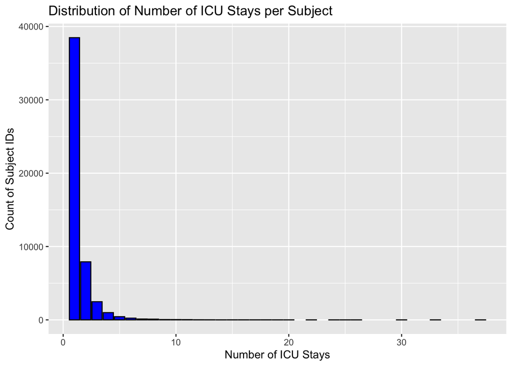

```r
ggplot(icu_stays_summary, aes(x = number_of_stays)) +
  geom_bar(fill = "blue", color = "black") +
  labs(title = "Distribution of Number of ICU Stays per Subject",
       x = "Number of ICU Stays",
       y = "Count of Subject IDs")
```

## Q3. `admissions` data

Information of the patients admitted into hospital is available in `admissions.csv.gz`. See https://mimic.mit.edu/docs/iv/modules/hosp/admissions/ for details of each field in this file. The first 10 lines are

```bash
zcat < ~/mimic/hosp/admissions.csv.gz | head
```

```
subject_id,hadm_id,admittime,dischtime,deathtime,admission_type,admit_provider_id,admission_location,discharge_location,insurance,language,marital_status,race,edregtime,edouttime,hospital_expire_flag
10000032,22595853,2180-05-06 22:23:00,2180-05-07 17:15:00,,URGENT,P874LG,TRANSFER FROM HOSPITAL,HOME,Other,ENGLISH,WIDOWED,WHITE,2180-05-06 19:17:00,2180-05-06 23:30:00,0
10000032,22841357,2180-06-26 18:27:00,2180-06-27 18:49:00,,EW EMER.,P09Q6Y,EMERGENCY ROOM,HOME,Medicaid,ENGLISH,WIDOWED,WHITE,2180-06-26 15:54:00,2180-06-26 21:31:00,0
10000032,25742920,2180-08-05 23:44:00,2180-08-07 17:50:00,,EW EMER.,P60CC5,EMERGENCY ROOM,HOSPICE,Medicaid,ENGLISH,WIDOWED,WHITE,2180-08-05 20:58:00,2180-08-06 01:44:00,0
10000032,29079034,2180-07-23 12:35:00,2180-07-25 17:55:00,,EW EMER.,P30KEH,EMERGENCY ROOM,HOME,Medicaid,ENGLISH,WIDOWED,WHITE,2180-07-23 05:54:00,2180-07-23 14:00:00,0
10000068,25022803,2160-03-03 23:16:00,2160-03-04 06:26:00,,EU OBSERVATION,P51VDL,EMERGENCY ROOM,,Other,ENGLISH,SINGLE,WHITE,2160-03-03 21:55:00,2160-03-04 06:26:00,0
10000084,23052089,2160-11-21 01:56:00,2160-11-25 14:52:00,,EW EMER.,P6957U,WALK-IN/SELF REFERRAL,HOME HEALTH CARE,Medicare,ENGLISH,MARRIED,WHITE,2160-11-20 20:36:00,2160-11-21 03:20:00,0
10000084,29888819,2160-12-28 05:11:00,2160-12-28 16:07:00,,EU OBSERVATION,P63AD6,PHYSICIAN REFERRAL,,Medicare,ENGLISH,MARRIED,WHITE,2160-12-27 18:32:00,2160-12-28 16:07:00,0
10000108,27250926,2163-09-27 23:17:00,2163-09-28 09:04:00,,EU OBSERVATION,P38XXV,EMERGENCY ROOM,,Other,ENGLISH,SINGLE,WHITE,2163-09-27 16:18:00,2163-09-28 09:04:00,0
10000117,22927623,2181-11-15 02:05:00,2181-11-15 14:52:00,,EU OBSERVATION,P2358X,EMERGENCY ROOM,,Other,ENGLISH,DIVORCED,WHITE,2181-11-14 21:51:00,2181-11-15 09:57:00,0
```

### Q3.1 Ingestion

Import `admissions.csv.gz` as a tibble `admissions_tble`.

```r
admissions_tble <- read_csv("~/mimic/hosp/admissions.csv.gz") |>
  as_tibble() |>
  print(width = Inf)
```

```
# A tibble: 431,231 × 16
   subject_id  hadm_id admittime           dischtime           deathtime
        <dbl>    <dbl> <dttm>              <dttm>              <dttm>
 1   10000032 22595853 2180-05-06 22:23:00 2180-05-07 17:15:00 NA
 2   10000032 22841357 2180-06-26 18:27:00 2180-06-27 18:49:00 NA
 3   10000032 25742920 2180-08-05 23:44:00 2180-08-07 17:50:00 NA
 4   10000032 29079034 2180-07-23 12:35:00 2180-07-25 17:55:00 NA
 5   10000068 25022803 2160-03-03 23:16:00 2160-03-04 06:26:00 NA
 6   10000084 23052089 2160-11-21 01:56:00 2160-11-25 14:52:00 NA
 7   10000084 29888819 2160-12-28 05:11:00 2160-12-28 16:07:00 NA
 8   10000108 27250926 2163-09-27 23:17:00 2163-09-28 09:04:00 NA
 9   10000117 22927623 2181-11-15 02:05:00 2181-11-15 14:52:00 NA
10   10000117 27988844 2183-09-18 18:10:00 2183-09-21 16:30:00 NA
   admission_type    admit_provider_id admission_location     discharge_location
   <chr>             <chr>             <chr>                  <chr>
```

[output cut: 35 more lines]

### Q3.2 Summary and visualization

Summarize the following information by graphics and explain any patterns you see.

- number of admissions per patient
- admission hour (anything unusual?)
- admission minute (anything unusual?)
- length of hospital stay (from admission to discharge) (anything unusual?)

According to the [MIMIC-IV documentation](https://mimic.mit.edu/docs/iv/about/concepts/#date-shifting),

> All dates in the database have been shifted to protect patient confidentiality. Dates will be internally consistent for the same patient, but randomly distributed in the future. Dates of birth which occur in the present time are not true dates of birth. Furthermore, dates of birth which occur before the year 1900 occur if the patient is older than 89. In these cases, the patient’s age at their first admission has been fixed to 300.

#### Answer

```r
num_of_admission <- admissions_tble %>%
  group_by(subject_id) %>%
  summarise(number_of_admission = n_distinct(hadm_id))
num_of_admission
```

```
# A tibble: 180,733 × 2
   subject_id number_of_admission
        <dbl>               <int>
 1   10000032                   4
 2   10000068                   1
 3   10000084                   2
 4   10000108                   1
 5   10000117                   2
 6   10000248                   1
 7   10000280                   1
 8   10000560                   1
 9   10000635                   1
10   10000719                   1
# ℹ 180,723 more rows
```

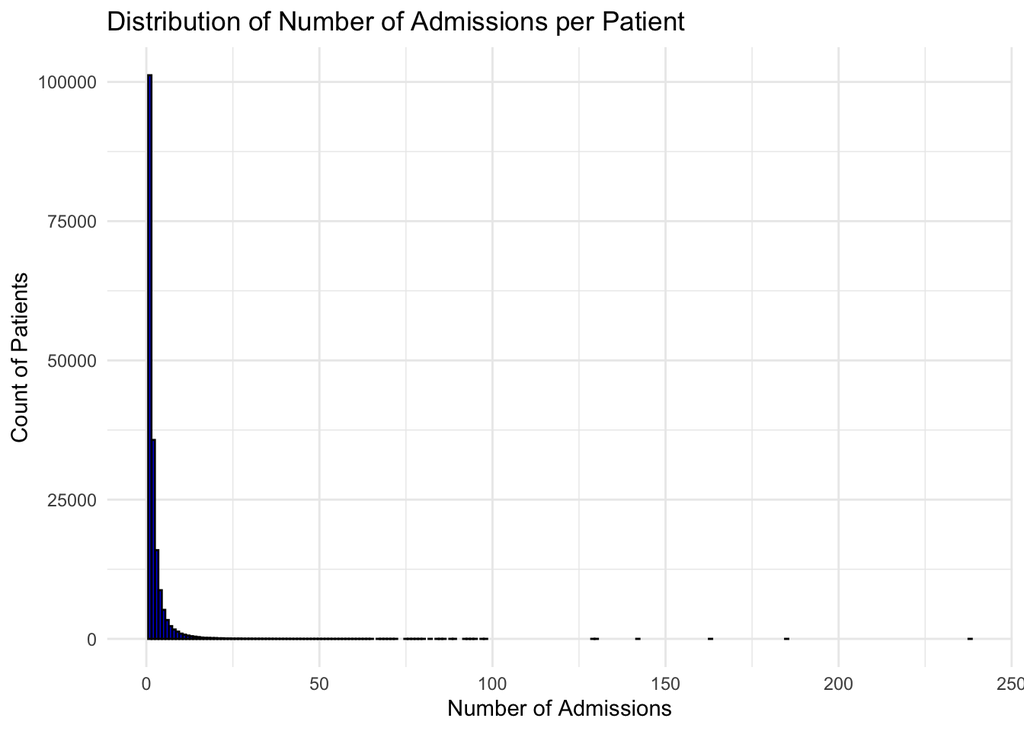

```r
ggplot(num_of_admission, aes(x = number_of_admission)) +
  geom_bar(fill = "blue", color = "black") +
  labs(title = "Distribution of Number of Admissions per Patient",
       x = "Number of Admissions",
       y = "Count of Patients") +
  theme_minimal()
```

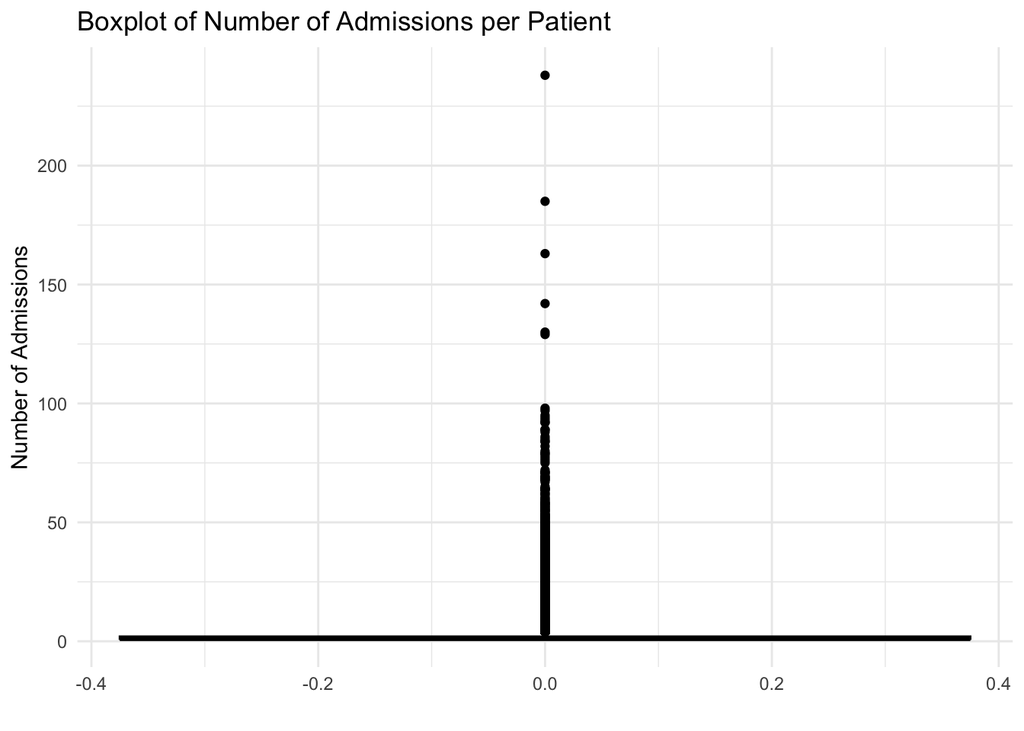

```r
ggplot(num_of_admission, aes(y = number_of_admission)) +
  geom_boxplot(fill = "lightblue", color = "black") +
  labs(title = "Boxplot of Number of Admissions per Patient",
       x = "",
       y = "Number of Admissions") +
  theme_minimal()
```

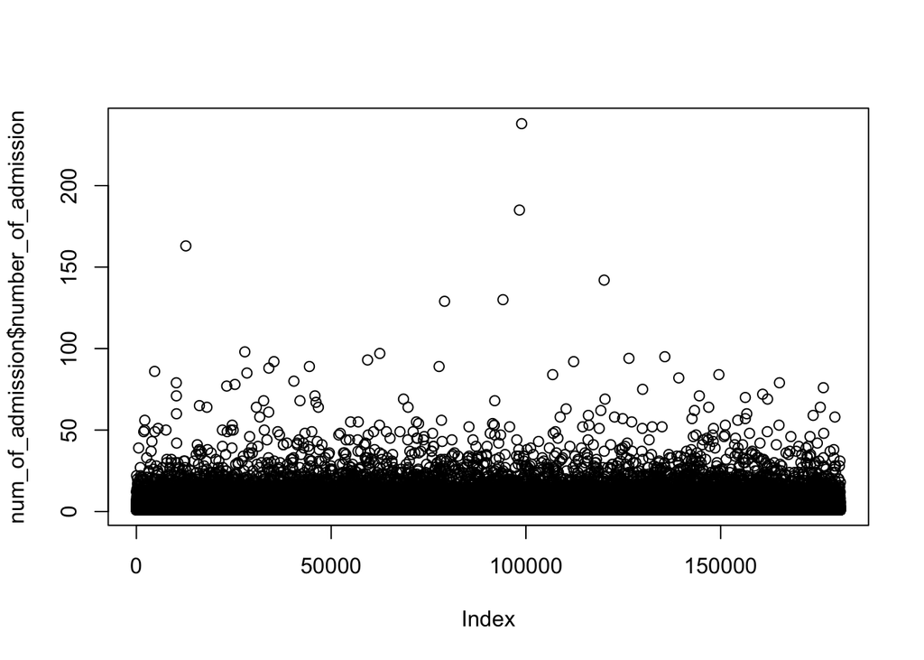

```r
plot(num_of_admission$number_of_admission)
```

```r
summary(num_of_admission$number_of_admission)
```

```
   Min. 1st Qu.  Median    Mean 3rd Qu.    Max.
  1.000   1.000   1.000   2.386   2.000 238.000
```

From the plot above, we notice that the number of admissions per patient is right-skewed. Most patients have 1 or 2 admissions. There are also some outliers and the maximum number of admissions per patient is 238.

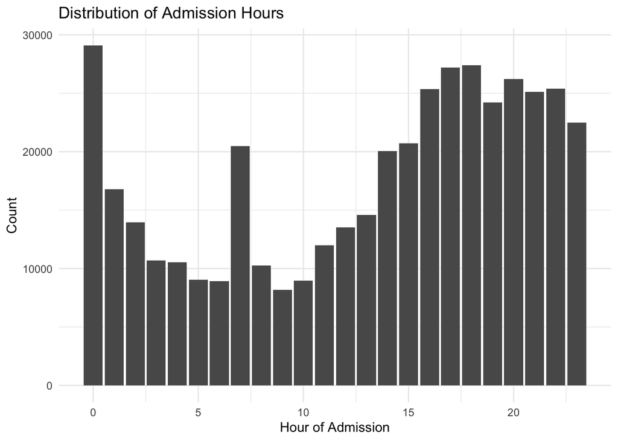

```r
admissions_tble <- admissions_tble |>
  mutate(admission_hour = hour(admittime))
ggplot(admissions_tble, aes(x = admission_hour)) +
  geom_bar() +
  labs(title = "Distribution of Admission Hours", x = "Hour of Admission", y = "Count") +
  theme_minimal()
```

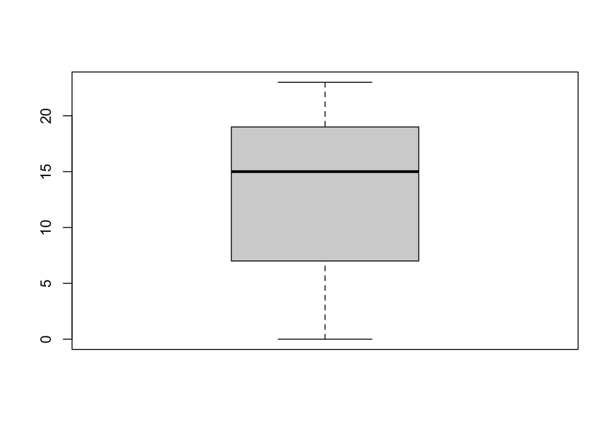

```r
boxplot(admissions_tble$admission_hour)
```

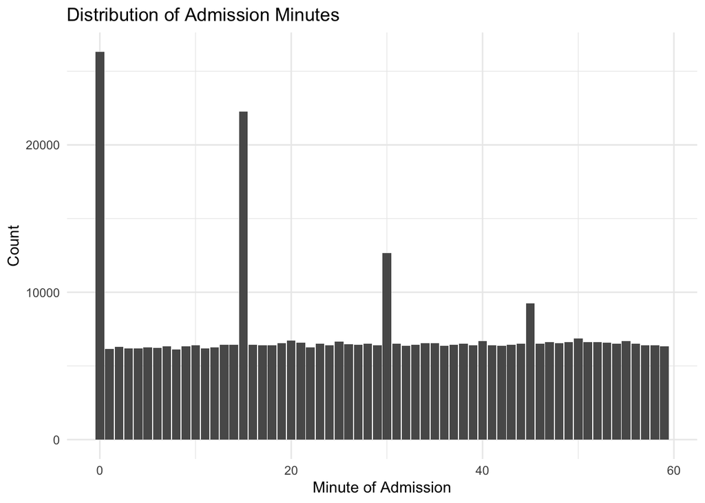

```r
admissions_tble <- admissions_tble %>%
  mutate(admission_minute = minute(admittime))
ggplot(admissions_tble, aes(x = admission_minute)) +
  geom_bar() +
  labs(title = "Distribution of Admission Minutes", x = "Minute of Admission", y = "Count") +
  theme_minimal()
```

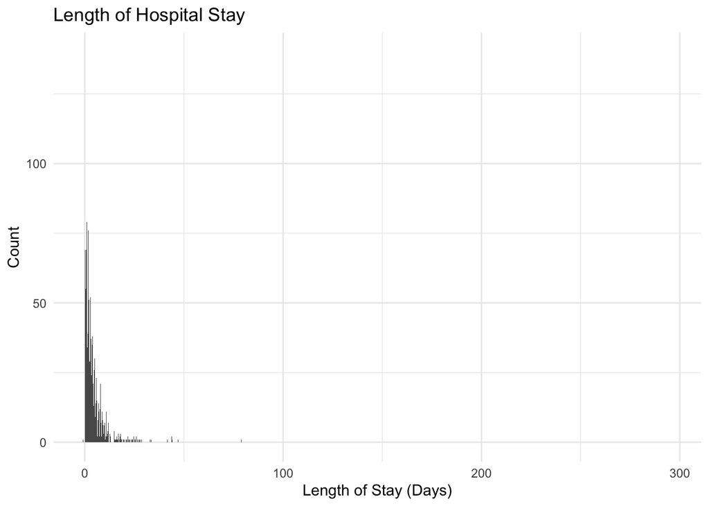

```r
admissions_tble <- admissions_tble %>%
  mutate(length_of_stay = as.numeric(difftime(dischtime, admittime, units = "days")))
ggplot(admissions_tble, aes(x = length_of_stay)) +
  geom_bar() +
  labs(title = "Length of Hospital Stay", x = "Length of Stay (Days)", y = "Count") +
  theme_minimal()
```

## Q4. `patients` data

Patient information is available in `patients.csv.gz`. See https://mimic.mit.edu/docs/iv/modules/hosp/patients/ for details of each field in this file. The first 10 lines are

```bash
zcat < ~/mimic/hosp/patients.csv.gz | head
```

```
subject_id,gender,anchor_age,anchor_year,anchor_year_group,dod
10000032,F,52,2180,2014 - 2016,2180-09-09
10000048,F,23,2126,2008 - 2010,
10000068,F,19,2160,2008 - 2010,
10000084,M,72,2160,2017 - 2019,2161-02-13
10000102,F,27,2136,2008 - 2010,
10000108,M,25,2163,2014 - 2016,
10000115,M,24,2154,2017 - 2019,
10000117,F,48,2174,2008 - 2010,
10000178,F,59,2157,2017 - 2019,
```

### Q4.1 Ingestion

Import `patients.csv.gz` (https://mimic.mit.edu/docs/iv/modules/hosp/patients/) as a tibble `patients_tble`.

#### Answer

```r
patients_tble <- read_csv("~/mimic/hosp/patients.csv.gz") |>
  as_tibble() |>
  print(width = Inf)
```

```
# A tibble: 299,712 × 6
   subject_id gender anchor_age anchor_year anchor_year_group dod
        <dbl> <chr>       <dbl>       <dbl> <chr>             <date>
 1   10000032 F              52        2180 2014 - 2016       2180-09-09
 2   10000048 F              23        2126 2008 - 2010       NA
 3   10000068 F              19        2160 2008 - 2010       NA
 4   10000084 M              72        2160 2017 - 2019       2161-02-13
 5   10000102 F              27        2136 2008 - 2010       NA
 6   10000108 M              25        2163 2014 - 2016       NA
 7   10000115 M              24        2154 2017 - 2019       NA
 8   10000117 F              48        2174 2008 - 2010       NA
 9   10000178 F              59        2157 2017 - 2019       NA
10   10000248 M              34        2192 2014 - 2016       NA
# ℹ 299,702 more rows
```

### Q4.2 Summary and visualization

Summarize variables `gender` and `anchor_age` by graphics, and explain any patterns you see.

#### Answer

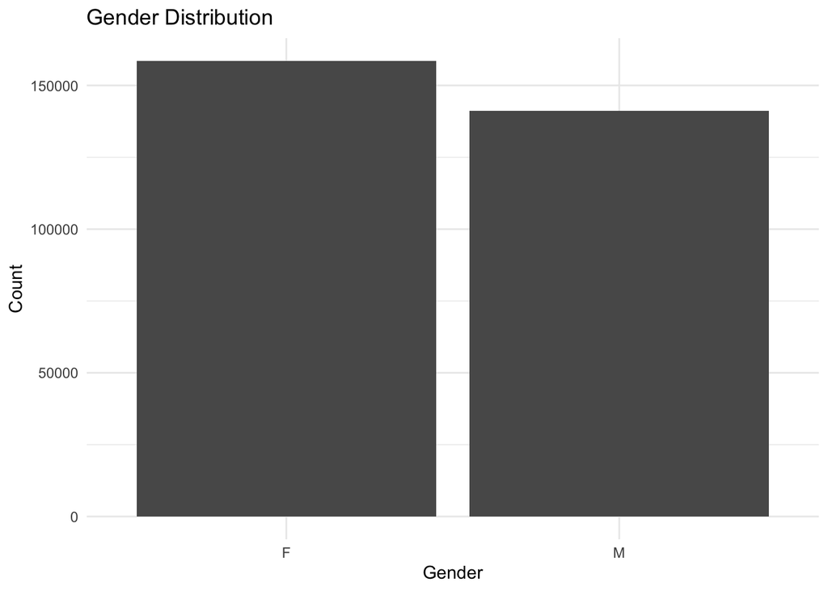

```r
patients_tble %>%
  ggplot() +
  geom_bar(aes(x = gender)) +
  theme_minimal() +
  labs(title = "Gender Distribution", x = "Gender", y = "Count")
```

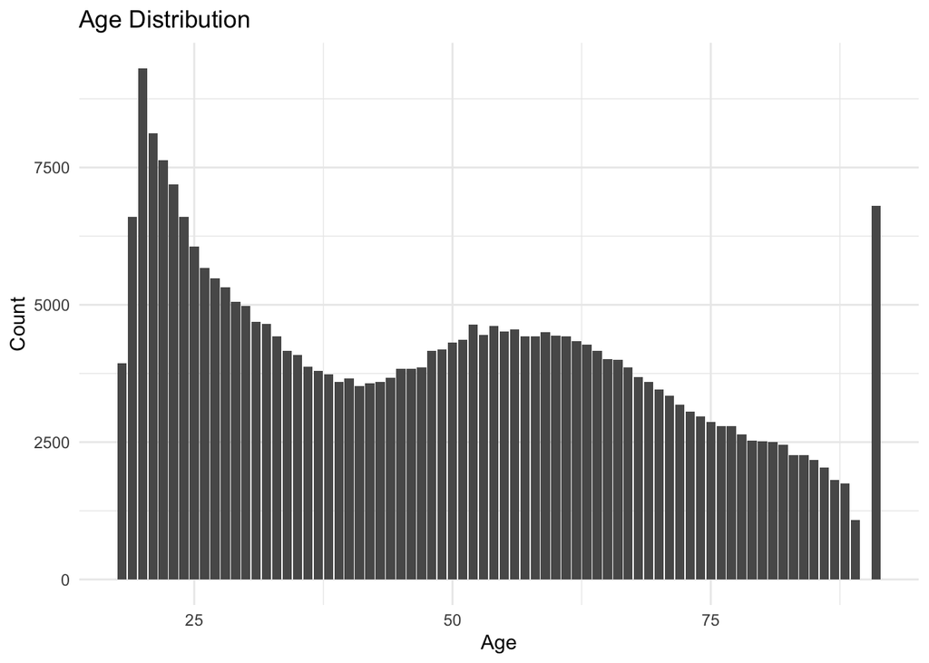

```r
patients_tble %>%
  ggplot() +
  geom_bar(aes(x = anchor_age), bins = 30) +
  theme_minimal() +
  labs(title = "Age Distribution", x = "Age", y = "Count")
```

## Q5. Lab results

`labevents.csv.gz` (https://mimic.mit.edu/docs/iv/modules/hosp/labevents/) contains all laboratory measurements for patients. The first 10 lines are

```bash
zcat < ~/mimic/hosp/labevents.csv.gz | head
```

```
labevent_id,subject_id,hadm_id,specimen_id,itemid,order_provider_id,charttime,storetime,value,valuenum,valueuom,ref_range_lower,ref_range_upper,flag,priority,comments
1,10000032,,45421181,51237,P28Z0X,2180-03-23 11:51:00,2180-03-23 15:15:00,1.4,1.4,,0.9,1.1,abnormal,ROUTINE,
2,10000032,,45421181,51274,P28Z0X,2180-03-23 11:51:00,2180-03-23 15:15:00,___,15.1,sec,9.4,12.5,abnormal,ROUTINE,VERIFIED.
3,10000032,,52958335,50853,P28Z0X,2180-03-23 11:51:00,2180-03-25 11:06:00,___,15,ng/mL,30,60,abnormal,ROUTINE,NEW ASSAY IN USE ___: DETECTS D2 AND D3 25-OH ACCURATELY.
4,10000032,,52958335,50861,P28Z0X,2180-03-23 11:51:00,2180-03-23 16:40:00,102,102,IU/L,0,40,abnormal,ROUTINE,
5,10000032,,52958335,50862,P28Z0X,2180-03-23 11:51:00,2180-03-23 16:40:00,3.3,3.3,g/dL,3.5,5.2,abnormal,ROUTINE,
6,10000032,,52958335,50863,P28Z0X,2180-03-23 11:51:00,2180-03-23 16:40:00,109,109,IU/L,35,105,abnormal,ROUTINE,
7,10000032,,52958335,50864,P28Z0X,2180-03-23 11:51:00,2180-03-23 16:40:00,___,8,ng/mL,0,8.7,,ROUTINE,MEASURED BY ___.
8,10000032,,52958335,50868,P28Z0X,2180-03-23 11:51:00,2180-03-23 16:40:00,12,12,mEq/L,8,20,,ROUTINE,
9,10000032,,52958335,50878,P28Z0X,2180-03-23 11:51:00,2180-03-23 16:40:00,143,143,IU/L,0,40,abnormal,ROUTINE,
```

`d_labitems.csv.gz` (https://mimic.mit.edu/docs/iv/modules/hosp/d_labitems/) is the dictionary of lab measurements.

```bash
zcat < ~/mimic/hosp/d_labitems.csv.gz | head
```

```
itemid,label,fluid,category
50801,Alveolar-arterial Gradient,Blood,Blood Gas
50802,Base Excess,Blood,Blood Gas
50803,"Calculated Bicarbonate, Whole Blood",Blood,Blood Gas
50804,Calculated Total CO2,Blood,Blood Gas
50805,Carboxyhemoglobin,Blood,Blood Gas
50806,"Chloride, Whole Blood",Blood,Blood Gas
50808,Free Calcium,Blood,Blood Gas
50809,Glucose,Blood,Blood Gas
50810,"Hematocrit, Calculated",Blood,Blood Gas
```

We are interested in the lab measurements of creatinine (50912), potassium (50971), sodium (50983), chloride (50902), bicarbonate (50882), hematocrit (51221), white blood cell count (51301), and glucose (50931). Retrieve a subset of `labevents.csv.gz` that only containing these items for the patients in `icustays_tble`. Further restrict to the last available measurement (by `storetime`) before the ICU stay. The final `labevents_tble` should have one row per ICU stay and columns for each lab measurement.

[figure not shown]

Hint: Use the Parquet format you generated in Homework 2. For reproducibility, make `labevents_pq` folder available at the current working directory `hw3`, for example, by a symbolic link.

```r
relevant_itemids <- c(50912, 50971, 50983, 50902, 50882, 51221, 51301, 50931)

labevents_filtered <- arrow::open_dataset("labevents_pq") |>
  filter(itemid %in% relevant_itemids, subject_id %in% icustays_tble$subject_id) |>
  select(subject_id, itemid, valuenum, storetime) |>
  collect() |>
  print(width = Inf)
```

```
# A tibble: 13,473,870 × 4
   subject_id itemid valuenum storetime
        <int>  <int>    <dbl> <dttm>
 1   10000032  50882     27   2180-03-23 09:40:00
 2   10000032  50902    101   2180-03-23 09:40:00
 3   10000032  50912      0.4 2180-03-23 09:40:00
 4   10000032  50971      3.7 2180-03-23 09:40:00
 5   10000032  50983    136   2180-03-23 09:40:00
 6   10000032  50931     95   2180-03-23 08:56:00
 7   10000032  51221     45.4 2180-03-23 08:19:00
 8   10000032  51301      3   2180-03-23 08:19:00
 9   10000032  51221     42.6 2180-05-06 15:42:00
10   10000032  51301      5   2180-05-06 15:42:00
# ℹ 13,473,860 more rows
```

```r
icustays_tble1 <- icustays_tble |>
  select(subject_id, intime, stay_id) |>
  print(width = Inf)
```

```
# A tibble: 73,181 × 3
   subject_id intime               stay_id
        <dbl> <dttm>                 <dbl>
 1   10000032 2180-07-23 14:00:00 39553978
 2   10000980 2189-06-27 08:42:00 39765666
 3   10001217 2157-11-20 19:18:02 37067082
 4   10001217 2157-12-19 15:42:24 34592300
 5   10001725 2110-04-11 15:52:22 31205490
 6   10001884 2131-01-11 04:20:05 37510196
 7   10002013 2160-05-18 10:00:53 39060235
 8   10002155 2131-03-09 21:33:00 32358465
 9   10002155 2129-08-04 12:45:00 33685454
10   10002155 2130-09-24 00:50:00 31090461
# ℹ 73,171 more rows
```

```r
aggregated_data <- labevents_filtered %>%
  left_join(icustays_tble1, by = "subject_id") %>%
  filter(storetime < intime) %>%
  group_by(subject_id, stay_id, itemid) %>%
  summarize(last_measurement = last(valuenum, order_by = storetime)) %>%
  collect() %>%
  print(width = Inf)
```

```
# A tibble: 525,174 × 4
# Groups:   subject_id, stay_id [68,467]
   subject_id  stay_id itemid last_measurement
        <dbl>    <dbl>  <int>            <dbl>
 1   10000032 39553978  50882             25
 2   10000032 39553978  50902             95
 3   10000032 39553978  50912              0.7
 4   10000032 39553978  50931            102
 5   10000032 39553978  50971              6.7
 6   10000032 39553978  50983            126
 7   10000032 39553978  51221             41.1
 8   10000032 39553978  51301              6.9
 9   10000980 39765666  50882             21
10   10000980 39765666  50902            109
# ℹ 525,164 more rows
```

```r
d_labitems <- read_csv("~/mimic/hosp/d_labitems.csv.gz") |>
  as_tibble() |>
  print(width = Inf)
```

```
# A tibble: 1,622 × 4
   itemid label                               fluid category
    <dbl> <chr>                               <chr> <chr>
 1  50801 Alveolar-arterial Gradient          Blood Blood Gas
 2  50802 Base Excess                         Blood Blood Gas
 3  50803 Calculated Bicarbonate, Whole Blood Blood Blood Gas
 4  50804 Calculated Total CO2                Blood Blood Gas
 5  50805 Carboxyhemoglobin                   Blood Blood Gas
 6  50806 Chloride, Whole Blood               Blood Blood Gas
 7  50808 Free Calcium                        Blood Blood Gas
 8  50809 Glucose                             Blood Blood Gas
 9  50810 Hematocrit, Calculated              Blood Blood Gas
10  50811 Hemoglobin                          Blood Blood Gas
# ℹ 1,612 more rows
```

```r
wide_data <- aggregated_data %>%
  pivot_wider(names_from = itemid, values_from = last_measurement)

print(wide_data, width = Inf)
```

```
# A tibble: 68,467 × 10
# Groups:   subject_id, stay_id [68,467]
   subject_id  stay_id `50882` `50902` `50912` `50931` `50971` `50983` `51221`
        <dbl>    <dbl>   <dbl>   <dbl>   <dbl>   <dbl>   <dbl>   <dbl>   <dbl>
 1   10000032 39553978      25      95     0.7     102     6.7     126    41.1
 2   10000980 39765666      21     109     2.3      89     3.9     144    27.3
 3   10001217 34592300      30     104     0.5      87     4.1     142    37.4
 4   10001217 37067082      22     108     0.6     112     4.2     142    38.1
 5   10001725 31205490      NA      98    NA        NA     4.1     139    NA
 6   10001884 37510196      30      88     1.1     141     4.5     130    39.7
 7   10002013 39060235      24     102     0.9     288     3.5     137    34.9
 8   10002155 31090461      23      98     2.8     117     4.9     135    25.5
 9   10002155 32358465      26      85     1.4     133     5.7     120    22.4
10   10002155 33685454      24     105     1.1     138     4.6     139    39.7
   `51301`
     <dbl>
 1     6.9
 2     5.3
 3     5.4
 4    15.7
 5    NA
 6    12.2
 7     7.2
 8    17.9
 9     9.8
10     7.9
# ℹ 68,457 more rows
```

```r
labevents_tble <- wide_data %>%
  rename(creatinine = `50912`, potassium = `50971`, sodium = `50983`, chloride = `50902`, bicarbonate = `50882`, hematocrit = `51221`, white_blood_cell_count = `51301`, glucose = `50931`)

print(labevents_tble, width = Inf)
```

```
# A tibble: 68,467 × 10
# Groups:   subject_id, stay_id [68,467]
   subject_id  stay_id bicarbonate chloride creatinine glucose potassium sodium
        <dbl>    <dbl>       <dbl>    <dbl>      <dbl>   <dbl>     <dbl>  <dbl>
 1   10000032 39553978          25       95        0.7     102       6.7    126
 2   10000980 39765666          21      109        2.3      89       3.9    144
 3   10001217 34592300          30      104        0.5      87       4.1    142
 4   10001217 37067082          22      108        0.6     112       4.2    142
 5   10001725 31205490          NA       98       NA        NA       4.1    139
 6   10001884 37510196          30       88        1.1     141       4.5    130
 7   10002013 39060235          24      102        0.9     288       3.5    137
 8   10002155 31090461          23       98        2.8     117       4.9    135
 9   10002155 32358465          26       85        1.4     133       5.7    120
10   10002155 33685454          24      105        1.1     138       4.6    139
   hematocrit white_blood_cell_count
        <dbl>                  <dbl>
 1       41.1                    6.9
 2       27.3                    5.3
 3       37.4                    5.4
 4       38.1                   15.7
 5       NA                     NA
 6       39.7                   12.2
 7       34.9                    7.2
 8       25.5                   17.9
 9       22.4                    9.8
10       39.7                    7.9
# ℹ 68,457 more rows
```

## Q6. Vitals from charted events

`chartevents.csv.gz` (https://mimic.mit.edu/docs/iv/modules/icu/chartevents/) contains all the charted data available for a patient. During their ICU stay, the primary repository of a patient’s information is their electronic chart. The `itemid` variable indicates a single measurement type in the database. The `value` variable is the value measured for `itemid`. The first 10 lines of `chartevents.csv.gz` are

```bash
zcat < ~/mimic/icu/chartevents.csv.gz | head
```

```
subject_id,hadm_id,stay_id,caregiver_id,charttime,storetime,itemid,value,valuenum,valueuom,warning
10000032,29079034,39553978,47007,2180-07-23 21:01:00,2180-07-23 22:15:00,220179,82,82,mmHg,0
10000032,29079034,39553978,47007,2180-07-23 21:01:00,2180-07-23 22:15:00,220180,59,59,mmHg,0
10000032,29079034,39553978,47007,2180-07-23 21:01:00,2180-07-23 22:15:00,220181,63,63,mmHg,0
10000032,29079034,39553978,47007,2180-07-23 22:00:00,2180-07-23 22:15:00,220045,94,94,bpm,0
10000032,29079034,39553978,47007,2180-07-23 22:00:00,2180-07-23 22:15:00,220179,85,85,mmHg,0
10000032,29079034,39553978,47007,2180-07-23 22:00:00,2180-07-23 22:15:00,220180,55,55,mmHg,0
10000032,29079034,39553978,47007,2180-07-23 22:00:00,2180-07-23 22:15:00,220181,62,62,mmHg,0
10000032,29079034,39553978,47007,2180-07-23 22:00:00,2180-07-23 22:15:00,220210,20,20,insp/min,0
10000032,29079034,39553978,47007,2180-07-23 22:00:00,2180-07-23 22:15:00,220277,95,95,%,0
```

`d_items.csv.gz` (https://mimic.mit.edu/docs/iv/modules/icu/d_items/) is the dictionary for the `itemid` in `chartevents.csv.gz`.

```bash
zcat < ~/mimic/icu/d_items.csv.gz | head
```

```
itemid,label,abbreviation,linksto,category,unitname,param_type,lownormalvalue,highnormalvalue
220001,Problem List,Problem List,chartevents,General,,Text,,
220003,ICU Admission date,ICU Admission date,datetimeevents,ADT,,Date and time,,
220045,Heart Rate,HR,chartevents,Routine Vital Signs,bpm,Numeric,,
220046,Heart rate Alarm - High,HR Alarm - High,chartevents,Alarms,bpm,Numeric,,
220047,Heart Rate Alarm - Low,HR Alarm - Low,chartevents,Alarms,bpm,Numeric,,
220048,Heart Rhythm,Heart Rhythm,chartevents,Routine Vital Signs,,Text,,
220050,Arterial Blood Pressure systolic,ABPs,chartevents,Routine Vital Signs,mmHg,Numeric,90,140
220051,Arterial Blood Pressure diastolic,ABPd,chartevents,Routine Vital Signs,mmHg,Numeric,60,90
220052,Arterial Blood Pressure mean,ABPm,chartevents,Routine Vital Signs,mmHg,Numeric,,
```

We are interested in the vitals for ICU patients: heart rate (220045), systolic non-invasive blood pressure (220179), diastolic non-invasive blood pressure (220180), body temperature in Fahrenheit (223761), and respiratory rate (220210). Retrieve a subset of `chartevents.csv.gz` only containing these items for the patients in `icustays_tble`. Further restrict to the first vital measurement within the ICU stay. The final `chartevents_tble` should have one row per ICU stay and columns for each vital measurement.

[figure not shown]

Hint: Use the Parquet format you generated in Homework 2. For reproducibility, make `chartevents_pq` folder available at the current working directory, for example, by a symbolic link.

## Q7. Putting things together

Let us create a tibble `mimic_icu_cohort` for all ICU stays, where rows are all ICU stays of adults (age at `intime` >= 18) and columns contain at least following variables

- all variables in `icustays_tble`
- all variables in `admissions_tble`
- all variables in `patients_tble`
- the last lab measurements before the ICU stay in `labevents_tble`
- the first vital measurements during the ICU stay in `chartevents_tble`

The final `mimic_icu_cohort` should have one row per ICU stay and columns for each variable.

[figure not shown]

## Q8. Exploratory data analysis (EDA)

Summarize the following information about the ICU stay cohort `mimic_icu_cohort` using appropriate numerics or graphs:

- Length of ICU stay `los` vs demographic variables (race, insurance, marital_status, gender, age at intime)
- Length of ICU stay `los` vs the last available lab measurements before ICU stay
- Length of ICU stay `los` vs the average vital measurements within the first hour of ICU stay
- Length of ICU stay `los` vs first ICU unit